# Dereplication feasibility – all 25 participants

### Both tiers together: co-assembly vs. single-sample as set overlaps

The same comparison as a set breakdown – clusters unique to single-sample assemblies, unique to the co-assembly, or shared between them, for both tiers. (A true UpSet dot-matrix plot was attempted here via patchwork, but hit a persistent axis-alignment bug combining discrete and continuous panels; with only 2 sets being compared, a grouped bar chart shows the identical information without the fragility.)

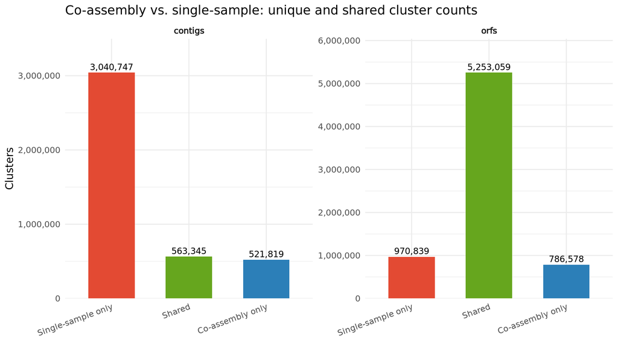

```r
sets <- read.delim(file.path(DP, "report_coassembly_vs_single_sets.tsv"))

set_levels <- c("single_only", "shared", "coassembly_only")
set_labels_full <- c(single_only = "Single-sample only", shared = "Shared", coassembly_only = "Co-assembly only")

sets_agg <- sets %>%
  group_by(tier, set) %>%
  summarise(n_clusters = sum(n_clusters), .groups = "drop") %>%
  mutate(set = factor(set, levels = set_levels))

ggplot(sets_agg, aes(x = set, y = n_clusters, fill = set)) +
  geom_col(width = 0.6) +
  geom_text(aes(label = scales::comma(n_clusters)), vjust = -0.4, size = 3.2) +
  facet_wrap(~tier, scales = "free_y") +
  scale_x_discrete(labels = set_labels_full) +
  scale_y_continuous(expand = expansion(mult = c(0, 0.15)), labels = scales::comma) +
  scale_fill_manual(values = c(single_only = "#e34a33", shared = "#66a61e", coassembly_only = "#2c7fb8"), guide = "none") +
  labs(x = NULL, y = "Clusters", title = "Co-assembly vs. single-sample: unique and shared cluster counts") +
  theme_minimal() +
  theme(axis.text.x = element_text(angle = 20, hjust = 1), strip.text = element_text(face = "bold"))
```

Genes: the “shared” bar dominates (5.25M of ~7.0M pooled cluster-instances) – consistent with the 90%+ gene-level redundancy already reported. Contigs: “single only” dominates instead (3.04M of ~4.1M) – most contig identity is still sample-specific even though a meaningful fraction (both “shared” and “co-assembly only”) is not, matching the more moderate ~40-45% contig-level redundancy already reported.

## 4. Co-assembly-unique contribution

Contigs/genes in a cluster with **no single-sample member at all** – only recoverable by pooling reads across timepoints, not by any individual single-sample assembly.

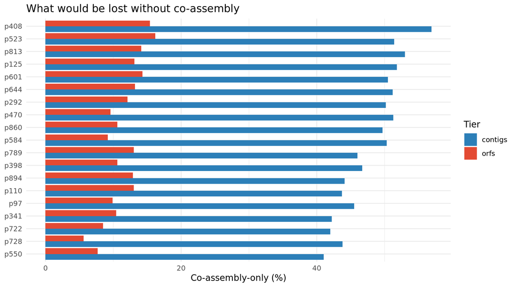

```r
ggplot(coassembly_unique, aes(x = reorder(participant, unique_pct), y = unique_pct, fill = tier)) +
  geom_col(position = "dodge") +
  scale_fill_manual(values = pal) +
  coord_flip() +
  labs(x = NULL, y = "Co-assembly-only (%)", fill = "Tier",
       title = "What would be lost without co-assembly") +
  theme_minimal()
```

**Caveat**: a co-assembly-only cluster could reflect genuinely novel sequence only assemblable with pooled coverage (the real win) – or a chimeric misassembly artifact from stitching together similar-but-distinct strain variants across timepoints (a known risk of pooled co-assembly). This number doesn’t distinguish the two.

**Concretely, for AMR genes specifically**: 607 real resistance gene hits across all 19 co-assembly participants were found *only* via the co-assembly – no single-sample assembly recovered them independently.

```r
amr_coassembly_unique %>%
  count(aro_call, sort = TRUE) %>%
  head(15) %>%
  kable(col.names = c("ARO call", "count"),
        caption = "Most frequent co-assembly-only AMR gene calls")
```

Most frequent co-assembly-only AMR gene calls

| ARO call | count |
| --- | --- |
| vanW gene in vanI cluster | 162 |
| vanT gene in vanG cluster | 116 |
| vanY gene in vanB cluster | 68 |
| vanY gene in vanG cluster | 40 |
| vanG | 25 |
| vanY gene in vanM cluster | 19 |
| vanH gene in vanO cluster | 15 |
| vanY gene in vanF cluster | 15 |
| vanY gene in vanA cluster | 12 |
| tet(M) | 10 |
| vanW gene in vanG cluster | 10 |
| qacG | 9 |
| tet(W/N/W) | 8 |
| poxtA | 7 |
| vanXY gene in vanG cluster | 7 |

## 5. AMR gene redundancy

```r
total_raw <- sum(amr_redundancy$raw_hits)
total_distinct <- sum(amr_redundancy$distinct_clusters)
pct_redundant <- 100 * (total_raw - total_distinct) / total_raw
```

Across all 296 assemblies, RGI reported **51,654** raw AMR gene hits, collapsing to **12,227** truly distinct AMR genes once dereplicated (**76.3%** redundant) – notably *lower* than the general gene-level redundancy (90%+), meaning AMR genes show more real diversity across timepoints/samples than a typical core gene.

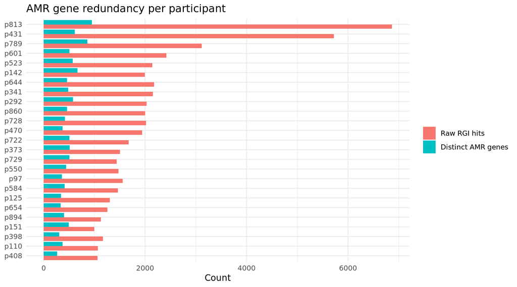

```r
amr_redundancy %>%
  pivot_longer(c(raw_hits, distinct_clusters), names_to = "type", values_to = "n") %>%
  mutate(type = factor(type, levels = c("raw_hits", "distinct_clusters"),
                        labels = c("Raw RGI hits", "Distinct AMR genes"))) %>%
  ggplot(aes(x = reorder(participant, n), y = n, fill = type)) +
  geom_col(position = "dodge") +
  coord_flip() +
  labs(x = NULL, y = "Count", fill = NULL,
       title = "AMR gene redundancy per participant") +
  theme_minimal()
```

## 6. Parameter sensitivity sweep

```r
kable(sweep, digits = 1,
      col.names = c("Participant", "Tier", "Setting", "Redundant (count %)", "Redundant (bp %)"))
```

| Participant | Tier | Setting | Redundant (count %) | Redundant (bp %) |
| --- | --- | --- | --- | --- |
| p110 | contigs | cov-mode 2 (original) | 43.9 | 71.4 |
| p110 | contigs | cov-mode 0 | 20.8 | 34.4 |
| p110 | orfs | min-seq-id 0.95 (original) | 93.2 | 96.0 |
| p110 | orfs | min-seq-id 0.99 | 90.6 | 94.0 |
| p97 | contigs | cov-mode 2 (original) | 42.0 | 73.3 |
| p97 | contigs | cov-mode 0 | 25.1 | 47.8 |
| p97 | orfs | min-seq-id 0.95 (original) | 96.5 | 98.0 |
| p97 | orfs | min-seq-id 0.99 | 94.4 | 96.4 |

Tier 2 (genes) is **robust** to identity threshold (95%->99% barely moves the number) – the gene-level redundancy signal is real, not a loose-threshold artifact. Tier 1 (contigs) is **highly sensitive** to `--cov-mode`: switching from containment-aware (query-coverage) to bidirectional coverage roughly halves the redundancy fraction – expected, since bidirectional coverage misses the “same region assembled to different lengths at different depths” scenario this analysis targets. The original settings (cov-mode 2, min-seq-id 0.95) were kept.

## 7. Propagation validation: does clustering predict identical annotation?

For clusters where >=2 members independently received a real hit from RGI (genes) or geNomad (contigs), do they agree?

```r
validation %>%
  group_by(tool) %>%
  summarise(testable = sum(testable), consistent = sum(consistent), inconsistent = sum(inconsistent)) %>%
  mutate(pct_consistent = round(100 * consistent / testable, 1)) %>%
  kable(col.names = c("Tool", "Testable clusters", "Consistent", "Inconsistent", "% consistent"))
```

| Tool | Testable clusters | Consistent | Inconsistent | % consistent |
| --- | --- | --- | --- | --- |
| RGI | 9411 | 9075 | 336 | 96.4 |
| geNomad | 29071 | 28503 | 568 | 98.0 |

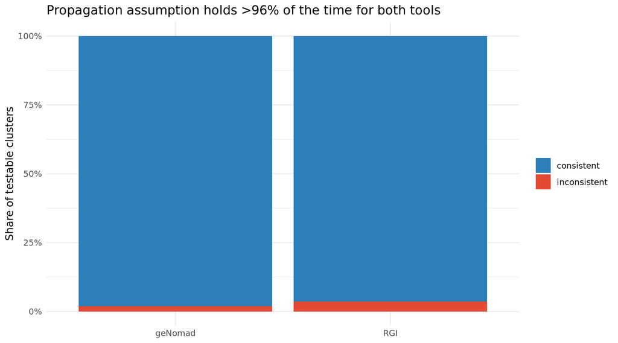

```r
validation %>%
  group_by(tool) %>%
  summarise(consistent = sum(consistent), inconsistent = sum(inconsistent)) %>%
  pivot_longer(c(consistent, inconsistent), names_to = "outcome", values_to = "n") %>%
  ggplot(aes(x = tool, y = n, fill = outcome)) +
  geom_col(position = "fill") +
  scale_y_continuous(labels = scales::percent) +
  scale_fill_manual(values = c(consistent = "#2c7fb8", inconsistent = "#e34a33")) +
  labs(x = NULL, y = "Share of testable clusters", fill = NULL,
       title = "Propagation assumption holds >96% of the time for both tools") +
  theme_minimal()
```

Both tools show strong (96-98%) agreement. The disagreements are **not random** – inspection of individual cases showed:

- RGI disagreements concentrate almost entirely on `vanY`/`vanT`/`vanXY` genes assigned to *different van-operon subtypes* (vanA vs vanB vs vanG vs vanM) – a known CARD/RGI database ambiguity for this highly homologous gene family, not a dereplication failure.
- geNomad disagreements are plasmid-vs-virus classification flips, consistent with genuine prophage-plasmid hybrid mobile elements the classifier finds genuinely borderline.

## 8. Gene & contig cluster longitudinal similarity within participant

For every pair of a participant’s own single-sample timepoints: what fraction of clusters do they share (Jaccard), vs. real calendar days between them – now for both tiers.

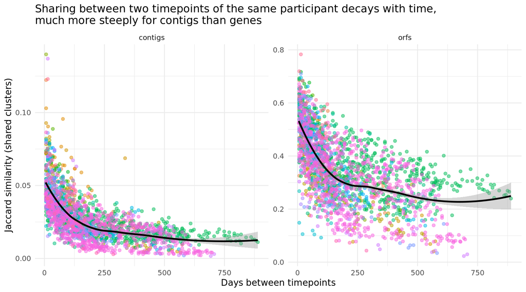

```r
ggplot(longitudinal, aes(x = days_between, y = jaccard)) +
  geom_point(aes(color = participant), alpha = 0.5, show.legend = FALSE) +
  geom_smooth(method = "loess", color = "black", se = TRUE) +
  facet_wrap(~tier, scales = "free_y") +
  labs(x = "Days between timepoints", y = "Jaccard similarity (shared clusters)",
       title = "Sharing between two timepoints of the same participant decays with time,\nmuch more steeply for contigs than genes") +
  theme_minimal()
```

Gene similarity is highest (~0.6-0.8) for timepoints ~1-2 weeks apart and drops substantially (~0.2-0.3) for timepoints roughly a year apart – real strain turnover, not noise. Contig similarity starts far lower (~0.14 at best) and decays to near-zero (~0.002-0.02) – contigs are longer, more structurally-specific sequences that reassemble consistently far less often than individual genes do, even within the same person over time. This matters directly for the propagation design: an “annotate once” representative may not stay valid indefinitely over a long study and could need periodic refresh, more urgently for contig-level than gene-level annotation.

## 9. Within- vs. between-participant sharing (second-level clustering)

Each participant’s own already-deduplicated representatives, clustered again across all 25 participants – a cluster with members from >1 participant means that sequence is shared across *different people*, not just across one person’s timepoints.

```r
cross_participant %>%
  group_by(tier) %>%
  summarise(
    within_only = sum(n_clusters[n_participants_in_cluster == 1]),
    between = sum(n_clusters[n_participants_in_cluster > 1]),
    total = sum(n_clusters)
  ) %>%
  mutate(pct_between = round(100 * between / total, 1)) %>%
  kable(col.names = c("Tier", "Within-participant only", "Between-participant", "Total", "% between"))
```

| Tier | Within-participant only | Between-participant | Total | % between |
| --- | --- | --- | --- | --- |
| contigs | 2424701 | 1056731 | 3481432 | 30.4 |
| orfs | 1446992 | 1147512 | 2594504 | 44.2 |

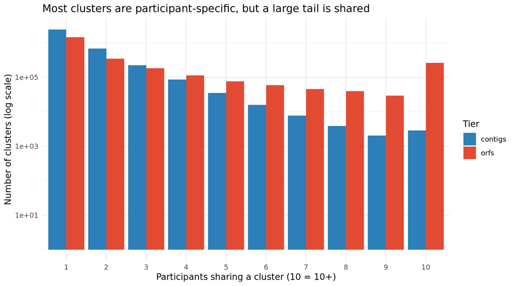

```r
cross_participant %>%
  mutate(n_participants_in_cluster = pmin(n_participants_in_cluster, 10)) %>%
  group_by(tier, n_participants_in_cluster) %>%
  summarise(n_clusters = sum(n_clusters), .groups = "drop") %>%
  ggplot(aes(x = factor(n_participants_in_cluster), y = n_clusters, fill = tier)) +
  geom_col(position = "dodge") +
  scale_fill_manual(values = pal) +
  scale_y_log10() +
  labs(x = "Participants sharing a cluster (10 = 10+)", y = "Number of clusters (log scale)",
       fill = "Tier", title = "Most clusters are participant-specific, but a large tail is shared") +
  theme_minimal()
```

Genes are shared across participants far more than contigs (44% vs. 30% of clusters span >=2 people) – genes are smaller, more conserved units that recombine/transfer more readily, while contigs carry more participant/strain-specific structural context. This means the *full* cohort dereplication opportunity is larger than the within-participant numbers above suggest – including real, concrete cases of the same AMR gene (e.g. `adeF`) recurring in different, unrelated participants.

## 10. Contig cluster x plasmid classification x AMR genes

```r
plasmid_amr %>%
  mutate(pct_amr = round(100 * n_amr_carrying / n_clusters, 2)) %>%
  kable(col.names = c("Category", "N clusters", "N AMR-carrying", "% AMR-carrying"))
```

| Category | N clusters | N AMR-carrying | % AMR-carrying |
| --- | --- | --- | --- |
| other | 5366483 | 27576 | 0.51 |
| plasmid | 57782 | 1187 | 2.05 |
| virus | 53127 | 282 | 0.53 |

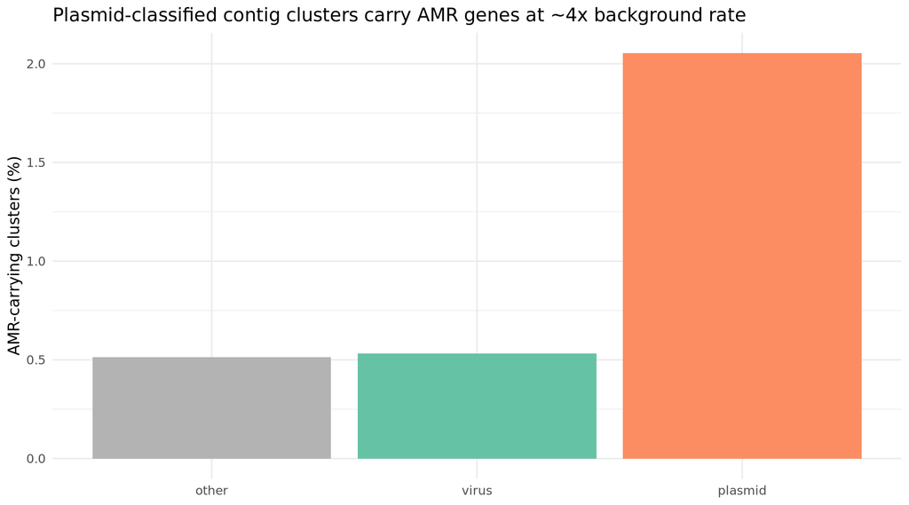

```r
plasmid_amr %>%
  mutate(pct_amr = 100 * n_amr_carrying / n_clusters,
         category = factor(category, levels = c("other", "virus", "plasmid"))) %>%
  ggplot(aes(x = category, y = pct_amr, fill = category)) +
  geom_col() +
  scale_fill_manual(values = c(other = "grey70", virus = "#66c2a5", plasmid = "#fc8d62"), guide = "none") +
  labs(x = NULL, y = "AMR-carrying clusters (%)",
       title = "Plasmid-classified contig clusters carry AMR genes at ~4x background rate") +
  theme_minimal()
```

Plasmid-classified contig clusters carry an AMR gene at roughly **4x** the background rate; virus-classified clusters show no enrichment over background – matches expected mobile-genetic-element biology (plasmids as a classic AMR reservoir/vector, unlike phages), recovered here from real, cluster-deduplicated data rather than assumed.

## 11. AMR gene dynamics: within- vs. between-participant

Section 5 counted distinct AMR genes *within* each participant separately (summed: 12,227). Here the same AMR-carrying clusters are pushed through the second-level (cross-participant) clustering to ask: how many are *actually* distinct once sharing between different people is also collapsed?

```r
within_total <- sum(amr_redundancy$distinct_clusters)
whole_cohort <- sum(amr_within_between$n_distinct_amr_genes)
shared_n <- sum(amr_within_between$n_distinct_amr_genes[amr_within_between$n_participants_sharing > 1])
data.frame(
  Level = c("Within-participant (summed)", "Whole-cohort (cross-participant dedup)"),
  `Distinct AMR genes` = c(within_total, whole_cohort),
  check.names = FALSE
) %>% kable()
```

| Level | Distinct AMR genes |
| --- | --- |
| Within-participant (summed) | 12227 |
| Whole-cohort (cross-participant dedup) | 2497 |

12,227 within-participant-distinct AMR genes collapse to just **2,497** once shared across different people too – a further **79.6%** reduction. **57.2%** of the whole-cohort-distinct AMR genes are found in >=2 participants.

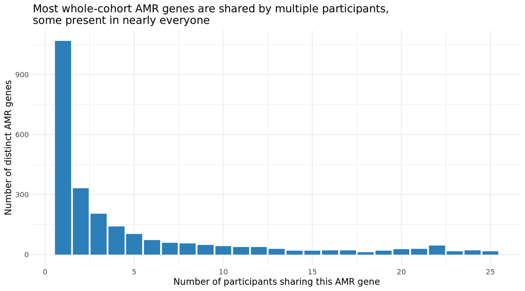

```r
ggplot(amr_within_between, aes(x = n_participants_sharing, y = n_distinct_amr_genes)) +
  geom_col(fill = "#2c7fb8") +
  labs(x = "Number of participants sharing this AMR gene", y = "Number of distinct AMR genes",
       title = "Most whole-cohort AMR genes are shared by multiple participants,\nsome present in nearly everyone") +
  theme_minimal()
```

A striking tail: some individual AMR genes recur in *most or all* 25 participants – consistent with a shared “core” resistance gene pool circulating in this population, distinct from the ~43% that are genuinely participant-specific (private resistance elements, or simply not yet detected elsewhere).

## 12. AMR plasmid dynamics: within- vs. between-participant

The same within-vs-between question, restricted to contig clusters that are **both** geNomad-plasmid-classified **and** AMR-gene-carrying (section 10) – is a given resistance plasmid participant-specific, or does it circulate across people?

```r
within_p <- sum(plasmid_amr$n_amr_carrying[plasmid_amr$category == "plasmid"])
whole_cohort_p <- sum(amr_plasmid_within_between$n_distinct_clusters)
shared_p <- sum(amr_plasmid_within_between$n_distinct_clusters[amr_plasmid_within_between$n_participants_sharing > 1])
data.frame(
  Level = c("Within-participant (summed)", "Whole-cohort (cross-participant dedup)"),
  `Distinct AMR+plasmid clusters` = c(within_p, whole_cohort_p),
  check.names = FALSE
) %>% kable()
```

| Level | Distinct AMR+plasmid clusters |
| --- | --- |
| Within-participant (summed) | 1187 |
| Whole-cohort (cross-participant dedup) | 1004 |

1187 within-participant AMR-carrying plasmid clusters collapse to **1004** whole-cohort distinct ones. Only **12%** are shared across >=2 participants – far less cross-participant sharing than plain AMR genes (section 11) show. This makes sense: matching a *whole plasmid* (a longer, multi-gene sequence) across different people’s distinct bacterial populations is a much stricter test than matching one gene.

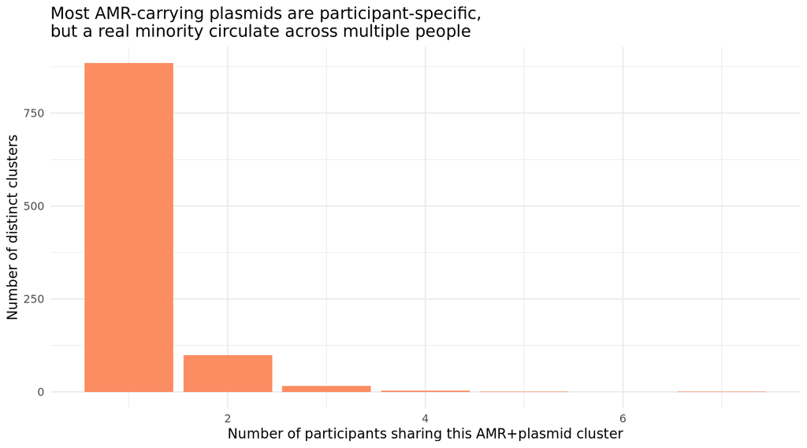

```r
ggplot(amr_plasmid_within_between, aes(x = n_participants_sharing, y = n_distinct_clusters)) +
  geom_col(fill = "#fc8d62") +
  labs(x = "Number of participants sharing this AMR+plasmid cluster", y = "Number of distinct clusters",
       title = "Most AMR-carrying plasmids are participant-specific,\nbut a real minority circulate across multiple people") +
  theme_minimal()
```

The most-shared single AMR-carrying plasmid cluster in this cohort was found in 7 different participants – real evidence of a circulating resistance plasmid, not coincidental sequence similarity.

## 13. AMR gene presence/absence: within participant, across time

Sections 5, 11-12 reported redundancy as summary percentages. Here each whole-cohort-distinct AMR gene (from section 11) is tracked as a real presence/absence call per sample – “present” meaning that sample carries a gene clustering with that AMR gene’s reference hit at >=95% identity/90% coverage, whether or not RGI happened to call a hit on that specific sample’s own copy. This is the direct view of whether a given resistance gene persists, disappears, or reappears over a participant’s own timepoints, and how consistently it’s detected across the cohort.

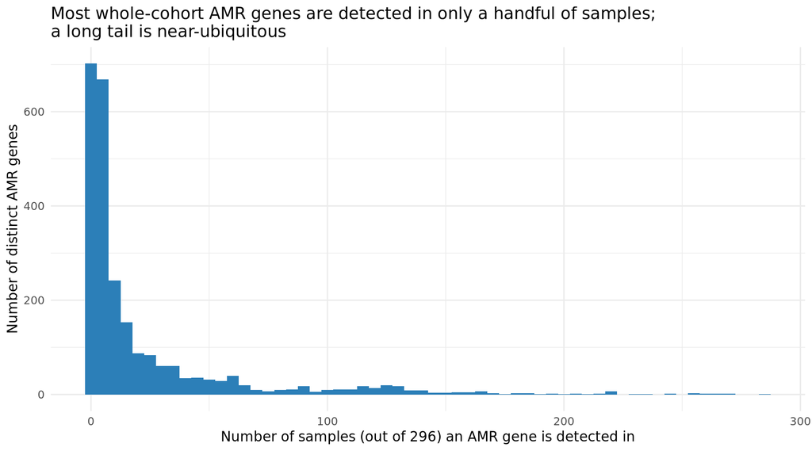

```r
ggplot(amr_prevalence, aes(x = n_samples)) +
  geom_histogram(binwidth = 5, fill = "#2c7fb8") +
  labs(x = "Number of samples (out of 296) an AMR gene is detected in",
       y = "Number of distinct AMR genes",
       title = "Most whole-cohort AMR genes are detected in only a handful of samples;\na long tail is near-ubiquitous") +
  theme_minimal()
```

Tiles are colored by the underlying contig’s own Tier-1 (contig-level) dereplication cluster – “Context 1”, “Context 2”, etc. per gene x participant, ranked by first appearance – so a color change between two timepoints means the gene reassembled on a genuinely different contig backbone, not just a different-looking assembly of the same one. Grey tiles mark a real sample that was collected but didn’t carry that gene, so absence is never confused with “no sample was taken” – a genuine gap in the grid means no sample exists near that date at all.

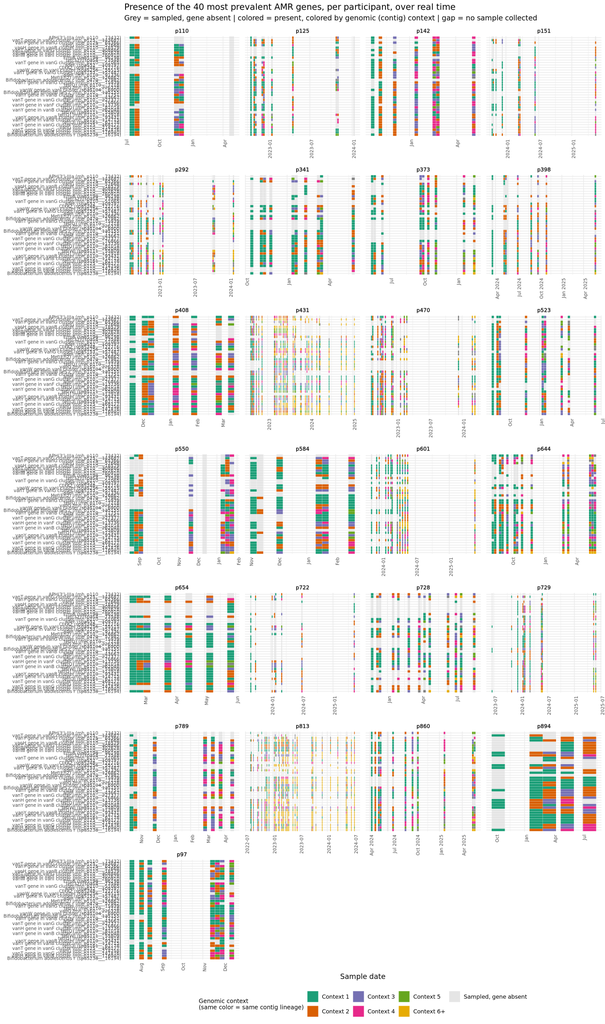

```r
top_genes <- amr_prevalence %>% slice_max(n_samples, n = 40) %>% pull(amr_gene)
gene_label <- amr_prevalence %>%
  filter(amr_gene %in% top_genes) %>%
  transmute(amr_gene, label = paste0(substr(aro_call, 1, 30), " (", amr_gene, ")"))

sample_calendar <- read.delim(file.path(DP, "report_sample_calendar.tsv")) %>%
  mutate(date = as.Date(date))

presence_top <- amr_presence %>%
  filter(amr_gene %in% top_genes, !is_coassembly, date != "")

# Rank each gene's distinct contig-cluster contexts by first appearance, per participant,
# so colors are meaningful within a row without needing raw (per-sample, non-comparable) IDs.
context_rank <- presence_top %>%
  filter(contig_cluster != "") %>%
  mutate(date = as.Date(date)) %>%
  arrange(amr_gene, participant, date) %>%
  distinct(amr_gene, participant, contig_cluster, .keep_all = TRUE) %>%
  group_by(amr_gene, participant) %>%
  mutate(context_label = paste0("Context ", pmin(row_number(), 6), ifelse(row_number() > 6, "+", ""))) %>%
  ungroup() %>%
  select(amr_gene, participant, contig_cluster, context_label)

presence_labeled <- presence_top %>%
  left_join(context_rank, by = c("amr_gene", "participant", "contig_cluster")) %>%
  transmute(amr_gene, group, participant, status = coalesce(context_label, "Context unresolved"))

relevant_participants <- unique(presence_labeled$participant)

grid <- tidyr::crossing(amr_gene = top_genes,
                         sample_calendar %>% filter(participant %in% relevant_participants)) %>%
  left_join(presence_labeled, by = c("amr_gene", "group", "participant")) %>%
  mutate(status = ifelse(is.na(status), "Sampled, gene absent", status)) %>%
  left_join(gene_label, by = "amr_gene")

status_colors <- c(
  "Sampled, gene absent" = "grey90",
  "Context 1" = "#1b9e77", "Context 2" = "#d95f02", "Context 3" = "#7570b3",
  "Context 4" = "#e7298a", "Context 5" = "#66a61e", "Context 6+" = "#e6ab02",
  "Context unresolved" = "grey50"
)

ggplot(grid, aes(x = date, y = reorder(label, match(amr_gene, top_genes)), fill = status)) +
  geom_tile(color = "white", linewidth = 0.1) +
  scale_fill_manual(values = status_colors, name = "Genomic context\n(same color = same contig lineage)") +
  facet_wrap(~participant, scales = "free_x", ncol = 4) +
  labs(x = "Sample date", y = NULL,
       title = "Presence of the 40 most prevalent AMR genes, per participant, over real time",
       subtitle = "Grey = sampled, gene absent | colored = present, colored by genomic (contig) context | gap = no sample collected") +
  theme_minimal(base_size = 11) +
  theme(axis.text.x = element_text(angle = 90, size = 7, hjust = 1),
        axis.text.y = element_text(size = 7),
        strip.text = element_text(size = 8, face = "bold"),
        legend.position = "bottom",
        legend.title = element_text(size = 9),
        panel.spacing = unit(0.6, "lines"))
```

Three real patterns visible directly: (1) some AMR genes, once detected in a participant, persist across most/all of their later timepoints – consistent with a stable resident strain carrying that resistance gene; (2) others appear intermittently against a background of genuine sampling (grey tiles either side), consistent with real strain turnover/loss, or detection-limit noise (present but at low enough abundance/coverage to sometimes fail assembly) – this analysis alone can’t distinguish the two; (3) where a persistent gene’s color changes between timepoints, the gene moved to a different contig/plasmid backbone rather than staying on the same one – worth flagging as a candidate for closer inspection (real mobilization, vs. an assembly-fragmentation artifact splitting the same true backbone differently across samples).

### Same grid, colored by contig length instead of context

Same participants, genes, dates and sample-collection background as above – only the fill changes, from categorical genomic context to the actual length (bp) of the underlying contig, so a change in shade between two timepoints shows whether the gene moved to a longer/shorter assembled backbone, not just a *different* one.

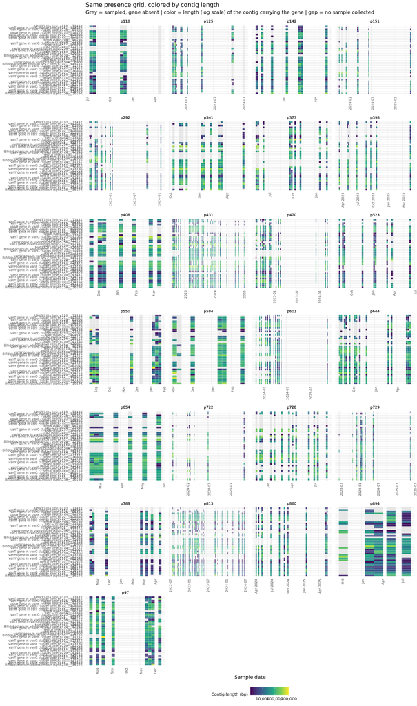

```r
grid_length <- tidyr::crossing(amr_gene = top_genes,
                                sample_calendar %>% filter(participant %in% relevant_participants)) %>%
  left_join(presence_top %>% select(amr_gene, group, participant, contig_length),
            by = c("amr_gene", "group", "participant")) %>%
  left_join(gene_label, by = "amr_gene")

ggplot(grid_length, aes(x = date, y = reorder(label, match(amr_gene, top_genes)), fill = contig_length)) +
  geom_tile(color = "white", linewidth = 0.1) +
  scale_fill_viridis_c(name = "Contig length (bp)", trans = "log10", na.value = "grey90",
                        labels = scales::comma) +
  facet_wrap(~participant, scales = "free_x", ncol = 4) +
  labs(x = "Sample date", y = NULL,
       title = "Same presence grid, colored by contig length",
       subtitle = "Grey = sampled, gene absent | color = length (log scale) of the contig carrying the gene | gap = no sample collected") +
  theme_minimal(base_size = 11) +
  theme(axis.text.x = element_text(angle = 90, size = 7, hjust = 1),
        axis.text.y = element_text(size = 7),
        strip.text = element_text(size = 8, face = "bold"),
        legend.position = "bottom",
        legend.title = element_text(size = 9),
        panel.spacing = unit(0.6, "lines"))
```

### A closer look at genuinely mobile genes (multiple real contexts)

[figure not shown]

```r
mobile <- context_rank %>%
  group_by(amr_gene, participant) %>%
  filter(n_distinct(context_label) >= 2) %>%
  ungroup()

if (nrow(mobile) > 0) {
  mobile_presence <- presence_top %>%
    inner_join(mobile %>% select(amr_gene, participant, contig_cluster, context_label),
               by = c("amr_gene", "participant", "contig_cluster")) %>%
    left_join(gene_label, by = "amr_gene") %>%
    mutate(gene_participant = paste0(label, " -- ", participant))

  ggplot(mobile_presence, aes(x = date, y = gene_participant, size = contig_length)) +
    geom_point(aes(color = context_label), alpha = 0.8) +
    scale_color_manual(values = status_colors, guide = "none") +
    scale_size_continuous(name = "Contig length (bp)", labels = scales::comma, range = c(2, 8)) +
    facet_wrap(~context_label, ncol = 1) +
    labs(x = "Sample date", y = NULL,
         title = sprintf("%d gene x participant pairs with >=2 real genomic contexts",
                          n_distinct(paste(mobile$amr_gene, mobile$participant))),
         subtitle = "Each panel = one context rank; point size = contig length at that timepoint") +
    theme_minimal(base_size = 10) +
    theme(axis.text.y = element_text(size = 7), strip.text = element_text(face = "bold"))
} else {
  cat("No gene x participant pairs among the top 40 genes showed >=2 distinct real contexts.\n")
}
```

## 14. Contig annotation atlas: length, genes, AMR, prevalence, plasmid/viral, MAG status

Every prior contig-level section looked at one or two dimensions at a time (redundancy, plasmid/AMR enrichment, presence/absence). Here each of the **103,036** whole-cohort-distinct contigs that are AMR-carrying and/or geNomad plasmid/virus-classified (the same “interesting” set section 10 uses, out of 5.48M total contig clusters – everything else is an uninformative singleton) gets a full annotation record: length, gene count, AMR gene count, how many samples/participants it’s found in, plasmid/virus classification, and its MAG binning record (via Binette – “good” = completeness >=50%, contamination <10%, the standard MAG-quality threshold; the co-assembly/single-sample Binette runs that produced this were part of this project’s separate binning workflow, not this dereplication pipeline).

MAG binning is done **independently per sample/assembly**, so the same whole-cohort contig can genuinely bin well in some participants’ assemblies and fail in others – confirmed on real data (a plasmid shared across 11 participants landed in a good-quality MAG in 4 of them, and was unbinned in the rest). A single flat “good MAG” label would hide that real heterogeneity, so each contig’s status reflects the actual fraction of its instances that binned well, not just whether any single one did.

```r
contig_summary %>%
  count(mag_status) %>%
  mutate(pct = round(100 * n / sum(n), 1)) %>%
  arrange(desc(n)) %>%
  kable(col.names = c("MAG status", "N contigs", "%"),
        caption = sprintf("MAG binning status across all %s interesting contigs", format(nrow(contig_summary), big.mark=",")))
```

MAG binning status across all 103,036 interesting contigs

| MAG status | N contigs | % |
| --- | --- | --- |
| never binned | 49011 | 47.6 |
| sometimes good MAG | 27229 | 26.4 |
| consistently good MAG | 25328 | 24.6 |
| binned, never good quality | 1468 | 1.4 |

Only a quarter of these AMR/plasmid/viral contigs bin *consistently* well (>=80% of their instances); a further quarter bin well only *sometimes* – real evidence that MAG status is often not a stable property of the sequence itself but depends on which specific sample’s assembly/coverage context it’s recovered in. Roughly half never bin well at all – consistent with a known binning limitation independent of the per-sample variability: plasmids and mobile elements often have coverage/composition signals that diverge from their host chromosome, so binners that rely on those signals systematically under-recover them, regardless of how real or important the sequence is.

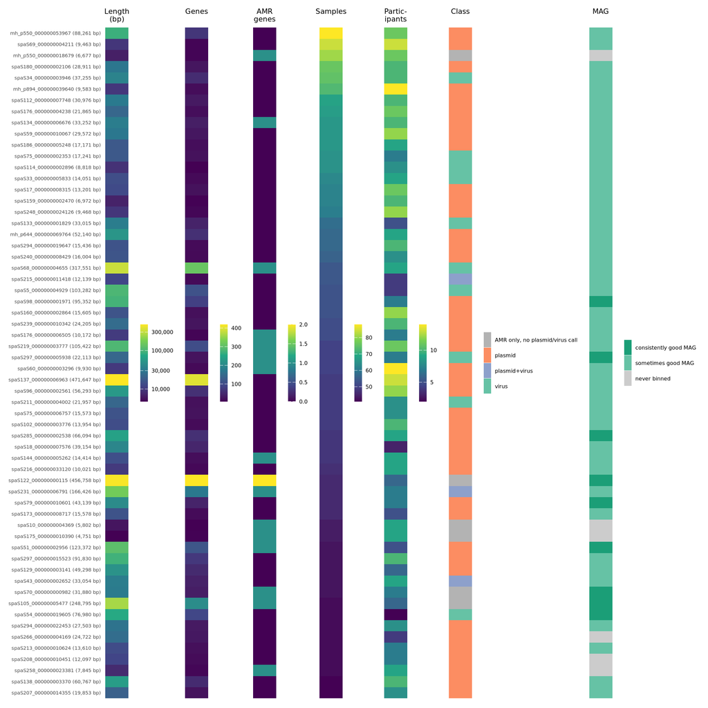

```r
top_contigs <- contig_summary %>%
  arrange(desc(n_samples), desc(length)) %>%
  slice_head(n = 60) %>%
  mutate(
    contig_label = paste0(whole_cohort_id, " (", scales::comma(length), " bp)"),
    classification = case_when(
      is_plasmid & is_virus ~ "plasmid+virus",
      is_plasmid ~ "plasmid",
      is_virus ~ "virus",
      TRUE ~ "AMR only, no plasmid/virus call"
    ),
    mag_status = factor(mag_status, levels = c("consistently good MAG", "sometimes good MAG", "binned, never good quality", "never binned"))
  )
y_order <- rev(top_contigs$contig_label)
top_contigs <- top_contigs %>% mutate(contig_label = factor(contig_label, levels = y_order))

base_theme <- theme_minimal(base_size = 8) +
  theme(axis.ticks = element_blank(), panel.grid = element_blank(),
        plot.title = element_text(size = 8, hjust = 0.5),
        legend.title = element_blank(), legend.text = element_text(size = 6),
        legend.key.width = unit(0.3, "cm"))

make_continuous_col <- function(var, title, trans = "identity", show_axis = FALSE) {
  ggplot(top_contigs, aes(x = 1, y = contig_label, fill = .data[[var]])) +
    geom_tile() +
    scale_fill_viridis_c(trans = trans, labels = scales::comma) +
    labs(title = title, x = NULL, y = NULL) +
    base_theme +
    theme(axis.text.x = element_blank(),
          axis.text.y = if (show_axis) element_text(size = 5.5) else element_blank())
}
make_discrete_col <- function(var, title, palette, show_axis = FALSE) {
  ggplot(top_contigs, aes(x = 1, y = contig_label, fill = .data[[var]])) +
    geom_tile() +
    scale_fill_manual(values = palette) +
    labs(title = title, x = NULL, y = NULL) +
    base_theme +
    theme(axis.text.x = element_blank(),
          axis.text.y = if (show_axis) element_text(size = 5.5) else element_blank())
}

col_length <- make_continuous_col("length", "Length\n(bp)", trans = "log10", show_axis = TRUE)
col_genes <- make_continuous_col("n_genes", "Genes")
col_amr <- make_continuous_col("n_amr_genes", "AMR\ngenes")
col_samples <- make_continuous_col("n_samples", "Samples")
col_participants <- make_continuous_col("n_participants", "Partic-\nipants")
col_class <- make_discrete_col("classification", "Class",
  c(plasmid = "#fc8d62", virus = "#66c2a5", `plasmid+virus` = "#8da0cb", `AMR only, no plasmid/virus call` = "grey70"))
col_mag <- make_discrete_col("mag_status", "MAG",
  c(`consistently good MAG` = "#1b9e77", `sometimes good MAG` = "#66c2a5",
    `binned, never good quality` = "#e6ab02", `never binned` = "grey80"))

# NOTE: patchwork's `|`/`/` operator overloads don't dispatch correctly against this
# ggplot2 version's new S7 object system in this env ("Can't find method for generic
# `|`" -- same underlying issue hit earlier in the co-assembly/single-sample UpSet
# attempt, worked around there by dropping patchwork entirely; here wrap_plots(), the
# function-based API, works fine since it doesn't rely on operator dispatch).
patchwork::wrap_plots(list(col_length, col_genes, col_amr, col_samples, col_participants, col_class, col_mag), nrow = 1)
```

### The same atlas, but as presence/absence over real time

Section 13 tracked *genes* as heatmap rows over real time; here it’s the same idea pivoted to *contigs* as the row – one row per whole-cohort-distinct contig (same top-60 set as above, same order), tracked across every real sample it could possibly appear in, with the annotation side-bars from the panel above attached directly. This is the same underlying concept the earlier gene-level heatmap already used – a “whole-cohort-distinct contig” is exactly the cluster-equivalence-class dereplication itself defines, so tracking one row across different participants/samples is consistent with, not an extension beyond, what the clustering already represents.

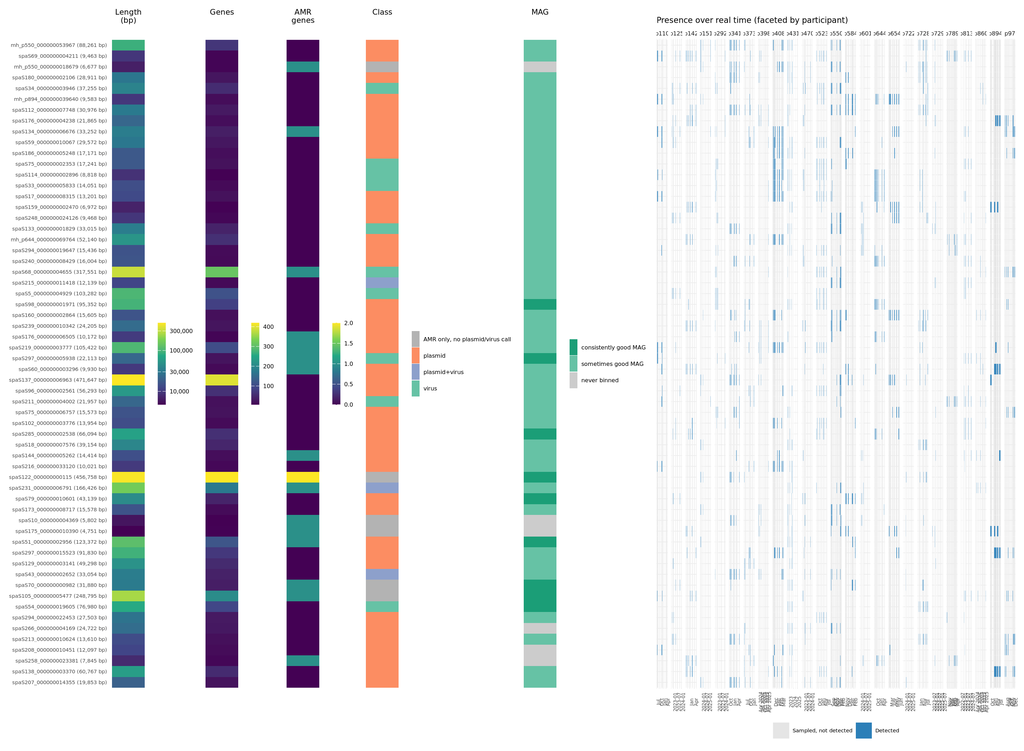

```r
contig_presence <- read.delim(file.path(DP, "report_contig_presence_absence.tsv")) %>%
  mutate(date = as.Date(ifelse(date == "", NA, date)))

relevant_contigs <- top_contigs$whole_cohort_id
relevant_participants_c <- contig_presence %>%
  filter(whole_cohort_id %in% relevant_contigs) %>% pull(participant) %>% unique()

contig_grid <- tidyr::crossing(
    whole_cohort_id = relevant_contigs,
    sample_calendar %>% filter(participant %in% relevant_participants_c)
  ) %>%
  left_join(contig_presence %>% filter(!is_coassembly) %>%
              select(whole_cohort_id, group, local_length),
            by = c("whole_cohort_id", "group")) %>%
  mutate(present = !is.na(local_length)) %>%
  left_join(top_contigs %>% select(whole_cohort_id, contig_label), by = "whole_cohort_id")

col_presence <- ggplot(contig_grid, aes(x = date, y = factor(contig_label, levels = y_order), fill = present)) +
  geom_tile(color = "white", linewidth = 0.05) +
  scale_fill_manual(values = c(`TRUE` = "#2c7fb8", `FALSE` = "grey90"),
                     labels = c(`TRUE` = "Detected", `FALSE` = "Sampled, not detected"), name = NULL) +
  facet_wrap(~participant, scales = "free_x", nrow = 1) +
  labs(x = NULL, y = NULL, title = "Presence over real time (faceted by participant)") +
  theme_minimal(base_size = 7) +
  theme(axis.text.x = element_text(angle = 90, size = 5), axis.text.y = element_blank(),
        strip.text = element_text(size = 6), legend.position = "bottom")

patchwork::wrap_plots(
  list(col_length, col_genes, col_amr, col_class, col_mag, col_presence),
  widths = c(1, 1, 1, 1, 1, 10), nrow = 1
)
```

Grey tiles mean the sample exists but that specific contig wasn’t detected in it – same “no data” vs. “genuinely absent” distinction the gene-level version enforces. A contig row that’s solid blue across most of a participant’s timepoints is a stable resident element; scattered detection against a grey background is the contig-level equivalent of the intermittent AMR genes already seen in section 13 – and now directly comparable against that same contig’s length/AMR-count/classification/MAG side-bars without cross-referencing a separate table.

### Per-participant view: AMR gene x contig, faceted by plasmid vs. MAG association

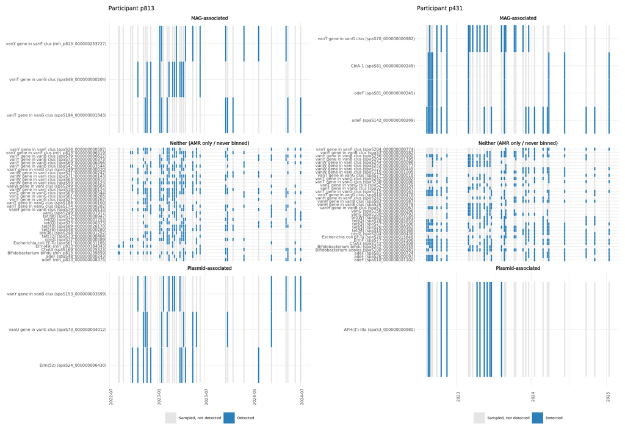

```r
make_gene_contig_participant_heatmap <- function(target_participant, top_n = 40) {
  p_presence <- amr_presence %>%
    filter(participant == target_participant, !is_coassembly, date != "", contig_cluster != "")

  top_pairs <- p_presence %>%
    count(amr_gene, contig_cluster, aro_call, name = "n_obs", sort = TRUE) %>%
    slice_head(n = top_n) %>%
    left_join(contig_summary %>% select(whole_cohort_id, is_plasmid, mag_status),
              by = c("contig_cluster" = "whole_cohort_id")) %>%
    mutate(
      row_label = paste0(substr(aro_call, 1, 22), " (", contig_cluster, ")"),
      facet_type = case_when(
        is_plasmid ~ "Plasmid-associated",
        mag_status %in% c("consistently good MAG", "sometimes good MAG") ~ "MAG-associated",
        TRUE ~ "Neither (AMR only / never binned)"
      )
    )

  cal <- sample_calendar %>% filter(participant == target_participant)
  presence_flag <- p_presence %>% distinct(amr_gene, contig_cluster, group) %>% mutate(present = TRUE)

  grid <- tidyr::crossing(top_pairs %>% select(amr_gene, contig_cluster, row_label, facet_type), cal) %>%
    left_join(presence_flag, by = c("amr_gene", "contig_cluster", "group")) %>%
    mutate(present = coalesce(present, FALSE))

  ggplot(grid, aes(x = date, y = row_label, fill = present)) +
    geom_tile(color = "white", linewidth = 0.1) +
    scale_fill_manual(values = c(`TRUE` = "#2c7fb8", `FALSE` = "grey90"),
                       labels = c(`TRUE` = "Detected", `FALSE` = "Sampled, not detected"), name = NULL) +
    facet_wrap(~facet_type, ncol = 1, scales = "free_y") +
    labs(x = NULL, y = NULL, title = sprintf("Participant %s", target_participant)) +
    theme_minimal(base_size = 7) +
    theme(axis.text.x = element_text(angle = 90, size = 6), axis.text.y = element_text(size = 6),
          strip.text = element_text(size = 7, face = "bold"), legend.position = "bottom")
}

# Two illustrative participants (most AMR presence records, richest real examples --
# same "show 2 example participants" pattern as the reference figure this was adapted from).
patchwork::wrap_plots(
  list(make_gene_contig_participant_heatmap("p813"), make_gene_contig_participant_heatmap("p431")),
  nrow = 1
)
```

Read each panel as: does this specific gene-on-this-specific-contig recur across this participant’s own timepoints, and is it riding on a plasmid, a binned chromosome, or neither? A gene appearing in *both* facets (once on a plasmid-classified contig, once on a MAG-associated one) is real evidence of the same resistance determinant existing on two genuinely different genomic backgrounds within the same person – worth a closer look candidate, not something the gene-only view in section 13 could show.

## 15. Two-step clustering validation: does the hierarchy miss real cross-participant matches?

The whole-cohort ORF/contig identity used throughout this report (e.g. section 9) is built in **two steps**: cluster within each participant first, then cluster only the within-participant *representatives* across participants. That second step has a known theoretical limitation – only one representative per within-participant cluster is ever compared cross-participant, so a real match can be missed if that specific representative happens not to be quite close enough, even though another member of the same cluster would have matched fine. This bias can only ever be **conservative** (undercount sharing, never invent it), but it had never been measured on real data.

```r
two_step_validation %>%
  summarise(
    aro_calls_tested = n(),
    split_confirmed = sum(!merged),
    missed_merge = sum(merged),
    total_original_clusters = sum(n_original_clusters),
    total_new_clusters = sum(n_new_clusters)
  ) %>%
  mutate(pct_missed_merge = round(100 * missed_merge / aro_calls_tested, 1),
         pct_cluster_reduction = round(100 * (total_original_clusters - total_new_clusters) / total_original_clusters, 1)) %>%
  kable(col.names = c("aro_call values tested", "Split confirmed", "Missed merge found",
                       "Total original clusters", "Total new clusters",
                       "% aro_calls affected", "% cluster reduction"))
```

| aro_call values tested | Split confirmed | Missed merge found | Total original clusters | Total new clusters | % aro_calls affected | % cluster reduction |
| --- | --- | --- | --- | --- | --- | --- |
| 112 | 81 | 31 | 2578 | 2494 | 27.7 | 3.3 |

```r
two_step_validation %>%
  filter(merged) %>%
  arrange(desc(n_original_clusters - n_new_clusters)) %>%
  transmute(aro_call, n_original_clusters, n_new_clusters,
            clusters_collapsed = n_original_clusters - n_new_clusters) %>%
  kable(col.names = c("aro_call", "Original clusters (two-step)", "New clusters (direct)", "Clusters collapsed"))
```

| aro_call | Original clusters (two-step) | New clusters (direct) | Clusters collapsed |
| --- | --- | --- | --- |
| vanY gene in vanG cluster | 152 | 134 | 18 |
| vanY gene in vanM cluster | 90 | 75 | 15 |
| vanW gene in vanI cluster | 470 | 461 | 9 |
| vanY gene in vanB cluster | 296 | 288 | 8 |
| tet(W) | 6 | 3 | 3 |
| qacG | 32 | 30 | 2 |
| vanG | 135 | 133 | 2 |
| vanT gene in vanG cluster | 479 | 477 | 2 |
| vanY gene in vanA cluster | 73 | 71 | 2 |
| vanY gene in vanF cluster | 99 | 97 | 2 |
| Bifidobacterium adolescentis rpoB mutants conferring resistance to rifampicin | 5 | 4 | 1 |
| Escherichia coli UhpT with mutation conferring resistance to fosfomycin | 2 | 1 | 1 |
| Escherichia coli emrE | 2 | 1 | 1 |
| Escherichia coli soxS with mutation conferring antibiotic resistance | 5 | 4 | 1 |
| FosA2 | 2 | 1 | 1 |
| H-NS | 2 | 1 | 1 |
| Klebsiella pneumoniae KpnH | 5 | 4 | 1 |
| PmrF | 5 | 4 | 1 |
| adeF | 64 | 63 | 1 |
| emrB | 4 | 3 | 1 |
| eptA | 2 | 1 | 1 |
| fosA5 | 4 | 3 | 1 |
| gadW | 2 | 1 | 1 |
| mdtB | 5 | 4 | 1 |
| nimG | 16 | 15 | 1 |
| poxtA | 28 | 27 | 1 |
| tet(32) | 9 | 8 | 1 |
| tet(M) | 4 | 3 | 1 |
| tet(O) | 4 | 3 | 1 |
| tet(O/W) | 2 | 1 | 1 |
| tet(W/N/W) | 4 | 3 | 1 |

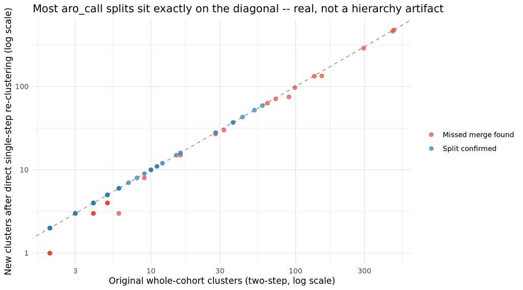

```r
two_step_validation %>%
  mutate(outcome = if_else(merged, "Missed merge found", "Split confirmed")) %>%
  ggplot(aes(x = n_original_clusters, y = n_new_clusters, color = outcome)) +
  geom_abline(slope = 1, intercept = 0, linetype = "dashed", color = "grey60") +
  geom_point(alpha = 0.7, size = 2) +
  scale_x_log10() + scale_y_log10() +
  scale_color_manual(values = c("Split confirmed" = "#2c7fb8", "Missed merge found" = "#e34a33")) +
  labs(x = "Original whole-cohort clusters (two-step, log scale)",
       y = "New clusters after direct single-step re-clustering (log scale)",
       color = NULL,
       title = "Most aro_call splits sit exactly on the diagonal -- real, not a hierarchy artifact") +
  theme_minimal()
```

**81 of 112 (72%) `aro_call` splits are confirmed real** – every original cluster stayed distinct even under direct, hierarchy-free comparison, meaning those ORFs really are different enough to be split, exactly as the two-step pipeline concluded. **31 of 112 (28%) show at least one real missed merge** – but the magnitude is small: across all 112 tested calls combined, only 84 of 2,578 total original clusters (3.3%) collapse under direct re-clustering. The effect concentrates almost entirely in the same highly diverse, hard-to-name gene families already flagged in section 7’s propagation check – `van`-operon genes (vanY/vanW/vanT/vanG across the vanA/B/F/G/I/M subtypes) and a handful of single-instance cases (`tet(W)`, `qacG`, `FosA2`). These are large gene families with many close alleles and known CARD/RGI naming ambiguity, not representative of AMR gene clustering generally.

**Conclusion**: the two-step hierarchy’s conservative bias is real but small and concentrated, not a broad correctness problem – it costs a few percent of extra splitting specifically among gene families that are already ambiguous by name, and never merges things that shouldn’t be merged (the reverse error is structurally impossible here). Scaling to the full cohort dereplication should expect this same small, gene-family-concentrated shortfall, not a systematic undercount across all AMR genes.

## 16. Dereplication summary: MAGs, AMR genes, plasmid contigs

Three entity types, three different real dereplication passes already run on this cohort – Binette bins collapsed to species-level genomes by dRep + GTDB-Tk (section on MAG taxonomy above), AMR ORFs collapsed to whole-cohort gene identity by this report’s own two-step `mmseqs2` clustering, and geNomad plasmid calls collapsed the same way at the contig level. This section pulls all three together: how many distinct, non-redundant entities does this cohort actually contain, and how are they distributed across participants (and, where a real date exists, across time)?

### 16.1 MAGs

**Important caveat**: co-assembly and single-assembly bins were dereplicated by dRep in two **separate, independent** runs (never compared to each other), so the same organism recovered in both a participant’s co-assembly and their own single-sample assemblies counts as two separate “dereplicated MAGs” below – a real limitation of the underlying data, not double-counted by choice.

```r
tibble(
  metric = c("Total Binette bins (both strands, all quality)", "...good-quality (>=50% completeness, <10% contamination)",
             "Bins entering dRep", "Dereplicated MAGs (species-level genomes)",
             "...shared across >=2 participants"),
  value = c(format(mag_totals$total_bins, big.mark = ","),
            format(mag_totals$good_mags, big.mark = ","),
            format(nrow(mag_instances), big.mark = ","),
            format(nrow(mag_derep), big.mark = ","),
            sprintf("%d (%.1f%%)", sum(mag_derep$n_participants > 1), 100 * mean(mag_derep$n_participants > 1)))
) %>% kable(col.names = c("Metric", "Value"))
```

| Metric | Value |
| --- | --- |
| Total Binette bins (both strands, all quality) | 9,996 |
| …good-quality (>=50% completeness, <10% contamination) | 9,656 |
| Bins entering dRep | 9,094 |
| Dereplicated MAGs (species-level genomes) | 1,175 |
| …shared across >=2 participants | 473 (40.3%) |

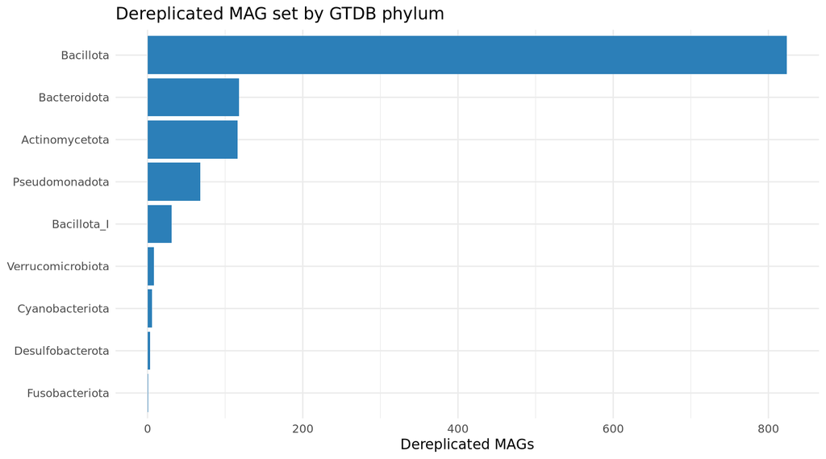

```r
mag_derep %>%
  filter(!is.na(phylum)) %>%
  count(phylum, sort = TRUE) %>%
  mutate(phylum = forcats::fct_reorder(phylum, n)) %>%
  ggplot(aes(x = phylum, y = n)) +
  geom_col(fill = "#2c7fb8") +
  coord_flip() +
  labs(x = NULL, y = "Dereplicated MAGs", title = "Dereplicated MAG set by GTDB phylum") +
  theme_minimal()
```

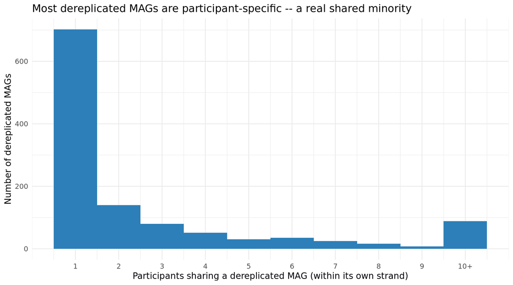

```r
ggplot(mag_derep, aes(x = pmin(n_participants, 10))) +
  geom_histogram(binwidth = 1, fill = "#2c7fb8") +
  scale_x_continuous(breaks = 1:10, labels = c(1:9, "10+")) +
  labs(x = "Participants sharing a dereplicated MAG (within its own strand)",
       y = "Number of dereplicated MAGs",
       title = "Most dereplicated MAGs are participant-specific -- a real shared minority") +
  theme_minimal()
```

```r
mag_per_participant %>%
  arrange(desc(n_dereplicated_mags)) %>%
  kable(col.names = c("Participant", "Dereplicated MAGs"))
```

| Participant | Dereplicated MAGs |
| --- | --- |
| p813 | 314 |
| p789 | 301 |
| p292 | 204 |
| p523 | 189 |
| p601 | 177 |
| p860 | 152 |
| p110 | 144 |
| p722 | 144 |
| p125 | 142 |
| p644 | 141 |
| p894 | 141 |
| p728 | 135 |
| p341 | 128 |
| p470 | 124 |
| p550 | 120 |
| p584 | 113 |
| p398 | 107 |
| p142 | 105 |
| p97 | 104 |
| p408 | 100 |
| p431 | 95 |
| p729 | 87 |
| p373 | 83 |
| p151 | 82 |
| p654 | 48 |

The most cohort-shared dereplicated MAGs (by number of participants carrying a bin from that species-level genome), tracked across real time for single-sample instances – same grid convention as section 13: grey means a real sample exists but no bin from that genome was recovered in it, color means present, colored by GTDB phylum.

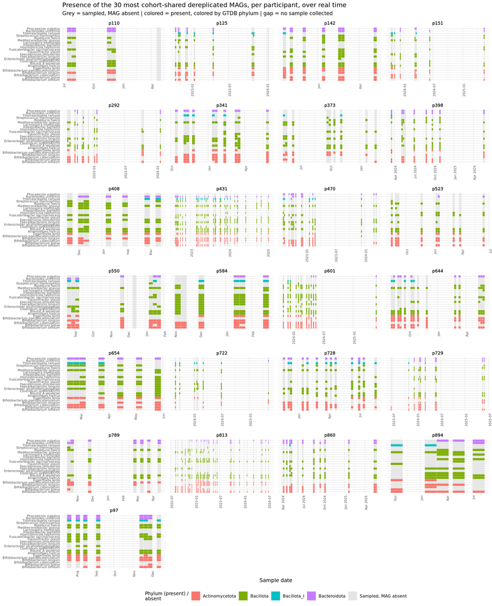

```r
top_mags <- mag_derep %>% filter(!is.na(gtdb_taxonomy)) %>% slice_max(n_participants, n = 30, with_ties = FALSE)

mag_label <- top_mags %>%
  transmute(dereplicated_mag_id, phylum,
            label = paste0(coalesce(str_extract(gtdb_taxonomy, "(?<=s__).+"), dereplicated_mag_id)))

mag_presence <- mag_instances %>%
  filter(dereplicated_mag_id %in% top_mags$dereplicated_mag_id, !is_coassembly, !is.na(date))

relevant_participants_mag <- unique(mag_presence$participant)

grid_mag <- tidyr::crossing(dereplicated_mag_id = top_mags$dereplicated_mag_id,
                             sample_calendar %>% filter(participant %in% relevant_participants_mag)) %>%
  left_join(mag_presence %>% distinct(dereplicated_mag_id, group, participant) %>% mutate(present = TRUE),
            by = c("dereplicated_mag_id", "group", "participant")) %>%
  left_join(mag_label, by = "dereplicated_mag_id") %>%
  mutate(fill_class = ifelse(is.na(present), "Sampled, MAG absent", phylum))

phylum_levels <- sort(unique(mag_label$phylum))
phylum_colors <- setNames(scales::hue_pal()(length(phylum_levels)), phylum_levels)
mag_fill_colors <- c(phylum_colors, "Sampled, MAG absent" = "grey90")

ggplot(grid_mag, aes(x = date, y = reorder(label, match(phylum, phylum_levels)), fill = fill_class)) +
  geom_tile(color = "white", linewidth = 0.1) +
  scale_fill_manual(values = mag_fill_colors, name = "Phylum (present) /\nabsent") +
  facet_wrap(~participant, scales = "free_x", ncol = 4) +
  labs(x = "Sample date", y = NULL,
       title = "Presence of the 30 most cohort-shared dereplicated MAGs, per participant, over real time",
       subtitle = "Grey = sampled, MAG absent | colored = present, colored by GTDB phylum | gap = no sample collected") +
  theme_minimal(base_size = 10) +
  theme(axis.text.x = element_text(angle = 90, size = 6, hjust = 1),
        axis.text.y = element_text(size = 6),
        strip.text = element_text(size = 8, face = "bold"),
        legend.position = "bottom", legend.title = element_text(size = 9),
        panel.spacing = unit(0.6, "lines"))
```

### 16.2 AMR genes, with real antibiotic class

`aro_call` names (`vanG`, `tetB(P)`, …) don’t say what drug they confer resistance to – RGI’s own raw output does (`Drug Class`, `Resistance Mechanism`, `AMR Gene Family` columns), joined in here for the first time.

```r
amr_prevalence %>%
  left_join(amr_drug_class, by = "aro_call") %>%
  count(drug_class_primary, name = "n_distinct_amr_genes", sort = TRUE) %>%
  kable(col.names = c("Drug class", "Distinct whole-cohort AMR genes"))
```

| Drug class | Distinct whole-cohort AMR genes |
| --- | --- |
| glycopeptide antibiotic | 1861 |
| tetracycline antibiotic | 146 |
| fluoroquinolone antibiotic | 133 |
| macrolide antibiotic | 65 |
| nitroimidazole antibiotic | 56 |
| aminoglycoside antibiotic | 43 |
| disinfecting agents and antiseptics | 43 |
| peptide antibiotic | 31 |
| cephalosporin | 15 |
| nucleoside antibiotic | 14 |
| phosphonic acid antibiotic | 14 |
| phenicol antibiotic | 13 |
| carbapenem | 12 |
| lincosamide antibiotic | 11 |
| aminocoumarin antibiotic | 10 |
| diaminopyrimidine antibiotic | 7 |
| cephamycin | 6 |
| monobactam | 5 |
| rifamycin antibiotic | 5 |
| elfamycin antibiotic | 2 |
| sulfonamide antibiotic | 2 |
| glycylcycline | 1 |
| mupirocin-like antibiotic | 1 |
| pleuromutilin antibiotic | 1 |

Same top-40 whole-cohort AMR genes, same per-participant/date grid as section 13 – but now colored by antibiotic drug class instead of genomic context, with rows grouped by class, directly answering “which resistances, to which drugs, are present in whom and when.”

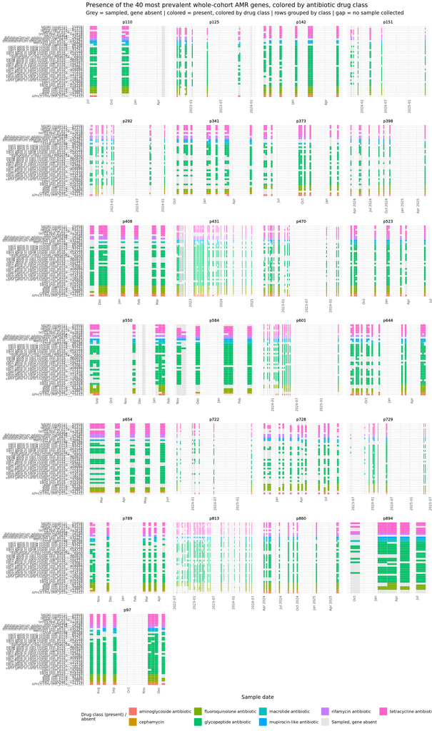

```r
gene_label_dc <- amr_prevalence %>%
  filter(amr_gene %in% top_genes) %>%
  left_join(amr_drug_class, by = "aro_call") %>%
  transmute(amr_gene, drug_class_primary = coalesce(drug_class_primary, "unknown"),
            label = paste0(substr(aro_call, 1, 28), " (", amr_gene, ")"))

grid_dc <- tidyr::crossing(amr_gene = top_genes,
                            sample_calendar %>% filter(participant %in% relevant_participants)) %>%
  left_join(presence_top %>% distinct(amr_gene, group, participant) %>% mutate(present = TRUE),
            by = c("amr_gene", "group", "participant")) %>%
  left_join(gene_label_dc, by = "amr_gene") %>%
  mutate(fill_class = ifelse(is.na(present), "Sampled, gene absent", drug_class_primary))

dc_levels <- sort(unique(gene_label_dc$drug_class_primary))
dc_colors <- setNames(scales::hue_pal()(length(dc_levels)), dc_levels)
dc_fill_colors <- c(dc_colors, "Sampled, gene absent" = "grey90")

ggplot(grid_dc, aes(x = date, y = reorder(label, match(drug_class_primary, dc_levels)), fill = fill_class)) +
  geom_tile(color = "white", linewidth = 0.1) +
  scale_fill_manual(values = dc_fill_colors, name = "Drug class (present) /\nabsent") +
  facet_wrap(~participant, scales = "free_x", ncol = 4) +
  labs(x = "Sample date", y = NULL,
       title = "Presence of the 40 most prevalent whole-cohort AMR genes, colored by antibiotic drug class",
       subtitle = "Grey = sampled, gene absent | colored = present, colored by drug class | rows grouped by class | gap = no sample collected") +
  theme_minimal(base_size = 11) +
  theme(axis.text.x = element_text(angle = 90, size = 7, hjust = 1),
        axis.text.y = element_text(size = 7),
        strip.text = element_text(size = 8, face = "bold"),
        legend.position = "bottom", legend.title = element_text(size = 9),
        panel.spacing = unit(0.6, "lines"))
```

### 16.3 geNomad plasmid contigs

```r
plasmid_derep <- contig_summary %>% filter(is_plasmid)

tibble(
  metric = c("Dereplicated plasmid contigs (whole-cohort)", "...shared across >=2 participants",
             "...also AMR-carrying"),
  value = c(format(nrow(plasmid_derep), big.mark = ","),
            sprintf("%d (%.1f%%)", sum(plasmid_derep$n_participants > 1), 100 * mean(plasmid_derep$n_participants > 1)),
            sprintf("%d (%.1f%%)", sum(plasmid_derep$has_amr), 100 * mean(plasmid_derep$has_amr)))
) %>% kable(col.names = c("Metric", "Value"))
```

| Metric | Value |
| --- | --- |
| Dereplicated plasmid contigs (whole-cohort) | 43,321 |
| …shared across >=2 participants | 8554 (19.7%) |
| …also AMR-carrying | 1326 (3.1%) |

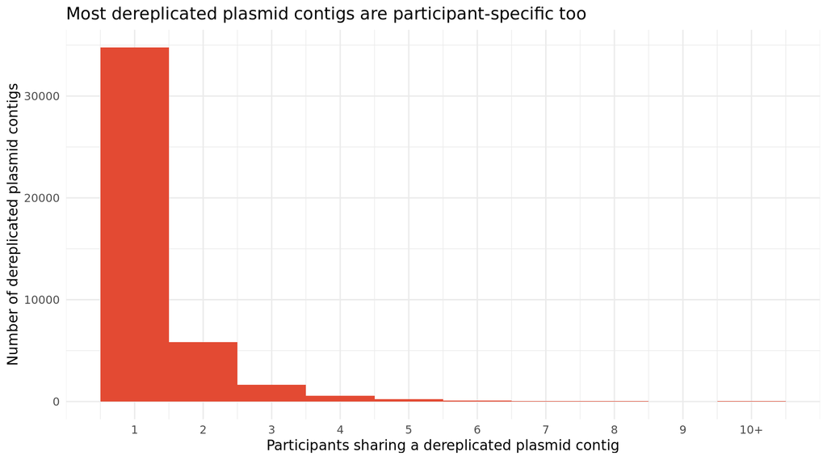

```r
ggplot(plasmid_derep, aes(x = pmin(n_participants, 10))) +
  geom_histogram(binwidth = 1, fill = "#e34a33") +
  scale_x_continuous(breaks = 1:10, labels = c(1:9, "10+")) +
  labs(x = "Participants sharing a dereplicated plasmid contig",
       y = "Number of dereplicated plasmid contigs",
       title = "Most dereplicated plasmid contigs are participant-specific too") +
  theme_minimal()
```

## Conclusions

Not yet done: per-tool propagation-safety audit beyond RGI/geNomad (the brainstorm’s original open question), and no representative-annotation + propagation pipeline has been built yet – this report is the evidence base for deciding whether to build one.